# チュートリアル

## tipインタープリターの起動

Linux等で端末を開き、シェルから以下のように起動します。

```
$ tip
```

シェルのコマンドパスにtipの実行ファイルのパスをセットする必要があります。

実行ファイルの作成方法は、 how to install を見て下さい。

## データ作成とプロット

```
tip> title "Plotting the data and fitting the curve"
tip> set x = {1,2,3,4,5,6,7,8,9,10}
tip> set y = 2*x*x
tip> plot x y (lw:0 st:star sc:red gd:1)
tip> fit x y quad (cp:1,200 lc:blue)
```

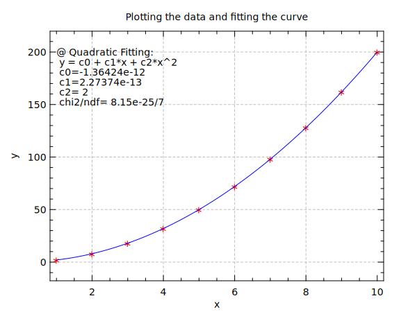

“title” はグラフ上部のタイトルテキストを指定します。  
“set” はデータのインスタンスを生成します。ここでデータとは数の配列です。  
“plot” はデータxとyの2次元のグラフを描きます。  
“fit” は指定された関数でフィッティングカーブを描きます。 この例では二次関数(Quadratic function)“quad”を用いています。

( ) で囲まれた引数はコマンドオプションです。

`(lw:0)` はグラフの線の幅を0にします、つまり線を描きません。  
`(st:star)` は シンボル（symbol）のスタイルを ‘star’（アスタリスク）にします。  
`(sc:red)` はシンボルの色（ color）を赤にします。  
`(gd:1)` はグラフの中にグリッドの点線を描くフラグをセットします。  
`(cp:1,200)` はコメントの位置をしていします。ここではフィッティングで得られた係数を グラフの座標で(x=1, y=200)の位置に描きます。  
`(lc:blue)` はグラフの線の色（ color）を青にします。

上の例のようにコマンド行の後ろに指定されたオプションはローカルオプション （その行のコマンドにのみ適用される）です。 一方、 以下のように、opt コマンドで指定されたオプションは グローバルオプションになります。

```
tip> opt (lw:0 st:star sc:red gd:1)
```

グローバルオプションは、この行以後のすべてのコマンドに適用されます。

## データ情報の表示

ユーザーが作成したデータの情報は ls コマンドで見ることができます。

```
tip> ls *
x : data(num) : size=10
y : data(num) : size=10
```

データの中身は catコマンドで見れます。

```
tip> cat y
y : data(num) :  2 8 18 32 50 72 98 128 162 200
```

## ファイルからのデータ読み出しとプロット

```
tip> title "Reading test.csv"
tip> read v test.csv (fs:",")
tip> xlab "1st column data"
tip> ylab "2nd and 3rd column data"
tip> plot v1 v2 (lc:red)
tip> plot v1 v3 (lc:blue rp:1)
```

この例では、`test.csv` は3列のデータからなるCSVのテキストファイルです。

“read” はファイルの中身を指定した変数に読み込みます。 変数名には列の番号が v1,v2,v3のように自動的に付加されます。 列の数が多いデータファイルの読むときに便利です。  
“xlab”/“ylab” はそれぞれ x座標、y座標のラベルを指定します。  
`(fs:",")` はフィールドセパレーターを指定するオプションで、ここではCSVファイルを列で分離するために`","`を指定しています。  
`(lc:red)`と`(lc:blue)` は線の色を指定しています。  
`(rp:1)`は’replot’オプションです。つまり既にあるグラフの上に上書きします。

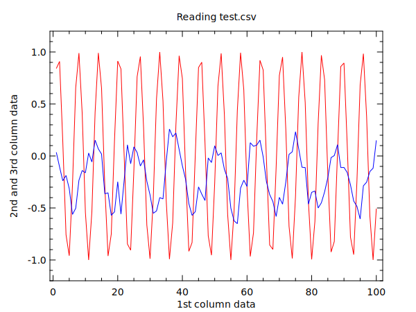

読み込むファイルの列数がそれほど多くないときは、 以下のように変数名をそれぞれの列で指定できます。

```
tip> read x,y,z test.csv (fs:",")
```

ここでは、1列目、2列目、3列目のデータがそれぞれ、変数 x, y, z に読み込まれています。

場合によっては、1列目のデータをx座標に、2列目以後のデータをy座標にしたいときが あります。そのような場合、以下のようにすることができます。

```
tip> read x,y test.csv (fs:",")
```

ここでは、xは１列目のデータ、yには2列目を起点とした列番号が付与されそれぞれy1,y2となります。

## フィルボックス, 線 テキストの描画

```
tip> title "Drawing fill box, line and text"
tip> read x,y test.csv (fs:",")
tip> xlab "x" ; ylab "y1, y2"
tip> plot x y1 (lc:red)
tip> plot x y2 (lc:blue rp:1)
tip> opt (rc:1)
tip> fbox 0.80 0.95 0.80 0.95 (ft:solid)
tip> line 0.82 0.86 0.90 0.90 (lc:red);  text 0.88 0.90 "y1"
tip> line 0.82 0.86 0.85 0.85 (lc:blue); text 0.88 0.85 "y2"
```

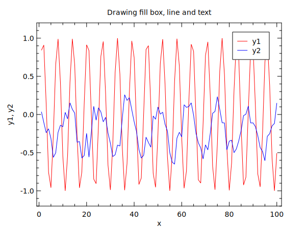

macro/tut02c.tip

“fbox” フィルボックスを描く。  
“line” 線を描く。  
“text” テキストを描く  
`(ft:solid)` 塗りつぶしスタイル（ fill-area-style）を “solid”にする。  
`(rc:1)` 相対座標に設定する。  
ここで相対座標では、x軸、y軸の範囲が両方とも0.0から1.0となる。

## 1次元ヒストグラム

```
tip> title "Histogram of Gaussian distribution (sigm=5,mean=10)"
tip> ylab "Num of entries"
tip> set x = random(100000,gaus,5,10)
tip> hplot x (nb:50)
tip> hfit x gaus (lc:green cp:0.03,0.9 rc:1 ts:0.8)
tip> stat x (cp:0.03,0.6 rc:1 ts:0.8)
```

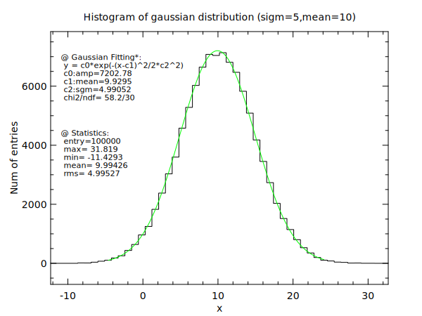

## 2次元ヒストグラム

```
tip> title "2D-Histogram of gaus.dist (sigm=5,mean=10 and sigm=8,mean=20)"
tip> zlab "Num of entries"
tip> set x = random(100000,gaus,5,10)
tip> set y = random(100000,gaus,8,20)
tip> hplot2 x y (nx:30 ny:30)
```

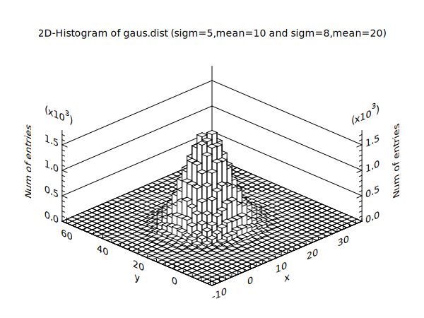

macro/tut04.tip

“hplot2” 指定された2つのデータから2次元ヒストグラムを生成しプロットする。  
`(nx:30)` and `(ny:30)` 2次元ヒストグラムのx軸、y軸のビン数を設定する。

## tipインタープリターを終了する

```
tip> q
```

コマンドヒストリーファイル `.tip_history`がカレントディレクトリに 保存される。

## マクロファイルの作成と実行

コマンドヒストリーのファイルをマクロファイルとしてコピーする。

```
$ cp .tip_history some_macro.tip
```

コピーしたマクロファイル`some_macro.tip`を編集する。

その後、`tip`を起動して以下のようにしてマクロファイルを実行する。

```
tip> exe some_macro.tip
```

## Colors

To find color names defined in tip, type `opt color` or `opt c`.

```
tip> opt color
color names of the symbol/line/fill :
 red(1), yellow(ylw,2), green(grn,3), aqua(aqu,4), pink(pnk,5)
 wheat(wht,6), gray(gry,7), brown(brn,8), blue(blu,9), violet(vio,10)
 cyan(cyn,11), turquoise(tqs,12), magenta(mgt,13), salmon(smn,14)
 black(blk,15)
```

## Symbols

To find symbols names defined in tip, type `opt symbol` or `opt s`.

```
tip> opt symbol
names of the symbol :
 non(0), dot(1), plus(pls,2), star(str,3), arc(4), cross(crs,5), square(sqr,6),
 triangle(tri,7), arccross(acc,8), arcdot(acd,9), square2(sq2,10),
 diamond(dia,11), star2(st2,12), square3(sq3,13), cross2(cr2,14), star3(st3,15),
 blacksqr,(bsq,16)
```

## Fill-Area-Style

To find fill-area names defined in tip, type `opt fill` or `opt f`.

```
tip> opt fill
names of the fill area style:
 null(-1), solid(s,0), hor(1), ver(2), p45(3), n45(4), p30(5), n30(6), hv(7), pn45(8)
```